# Teoría de Computación

[figure not shown]

# Curso de Pregrado 2026-1

## Información General

El curso de pregrado en Teoría de la Computación es una exploración profunda y rigurosa de los fundamentos matemáticos que sustentan la ciencia de la computación. Diseñado para proporcionar a los estudiantes una comprensión sólida de los conceptos teóricos subyacentes a la resolución de problemas computacionales, este curso abarca áreas clave como la teoría de autómatas, la complejidad computacional y la teoría de lenguajes formales. Los estudiantes se sumergirán en la investigación de modelos abstractos de cómputo, como máquinas de Turing, y explorarán cómo estas abstracciones pueden utilizarse para analizar la solubilidad de problemas algorítmicos. A lo largo del curso, se fomenta el pensamiento analítico y la capacidad para abordar problemas complejos desde una perspectiva teórica, preparando a los estudiantes para aplicar estos conocimientos en el diseño y análisis de algoritmos en diversos contextos informáticos.

Además, el curso abordará temas avanzados como la teoría de la complejidad computacional, donde se explorarán clases de problemas y se analizará la dificultad intrínseca de los mismos. Los estudiantes aprenderán a clasificar problemas según su complejidad y a comprender la diferencia entre problemas resolubles de manera eficiente y aquellos que son inherentemente difíciles. Con un enfoque en la formalización de conceptos y la aplicación de la lógica matemática en la teoría de la computación, este curso proporcionará a los estudiantes las herramientas necesarias para abordar desafíos computacionales desde una perspectiva fundamentada en principios sólidos y conceptualmente ricos.

### Objetivos

Comprender los Fundamentos Matemáticos: Proporcionar a los estudiantes una base sólida en conceptos matemáticos fundamentales, como la lógica, la teoría de conjuntos y la álgebra booleana, que son esenciales para el análisis teórico en ciencia de la computación.

Explorar Modelos de Cómputo Abstractos: Introducir y analizar modelos abstractos de cómputo, como máquinas de Turing y autómatas finitos, para comprender cómo representan y resuelven problemas algorítmicos.

Estudiar la Teoría de Lenguajes Formales: Profundizar en la teoría de lenguajes formales y gramáticas, permitiendo a los estudiantes comprender la estructura y la sintaxis de los lenguajes de programación y la base de compiladores.

## Profesor

[Taller Semana 3](https://www.dropbox.com/scl/fi/g0ngx54gnix30ntbf5rgt/TallerSemana3.pdf?rlkey=992xmc675ei6rpkf8rio4c7yx&dl=1)  
[Taller Semana 4](https://www.dropbox.com/scl/fi/5y5p9eb0nsnyda83v9765/Taller-Lenguajes-Regulares.pdf?rlkey=tcyh49j2pljqpsaw74yj5sljy&dl=1)

#### [M.Sc., Alfonso Meléndez Profesor Titular UECI](https://jamelende.github.io/PaginasWeb/HojadeVida/HojaDeVida2026.html)

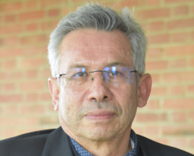

## Cronograma Semanal

### Texto del Curso :

Michael Sipser: [Introduction to the Theory of Computation](https://www.dropbox.com/scl/fi/tbljxputohw18pcy97oth/Michael-Sipser-Introduction-to-the-Theory-of-Computation-Thomson-South-Western-2012.pdf?rlkey=gb9woy8ki3fbgbp5ttvw9odis&dl=1)

### Slides Autómatas de Estado Finito Carnegie Mellon

[Slides](https://www.dropbox.com/scl/fi/zp7c3ctqszx94zbr1ho6g/ppt.zip?rlkey=nzqs487rpx1intfrq1h132fsj&dl=1)

[output not shown]

## Libros

[figure not shown]

[Lewis, Papadimitrou: Elements of the Theory of Computation](https://www.dropbox.com/scl/fi/78mpmcpvaqh24uku4ckpi/Harry-Lewis-Christos-H.-Papadimitriou-Elements-of-the-Theory-of-Computation-2nd-Edition-Prentice-Hall-1997.pdf?rlkey=nvgnidorw8p3kzjuazi26n121&dl=1)

Hopcroft, Ullman :Introduction to Automata Theory, Languages and Computation

[Sachin Agrawal: Theory of Computation](https://www.dropbox.com/scl/fi/tx9uu339e0i5feok2i6xh/Theory-of-Computation-Sachin-Agrawal-2018-511a6aac3e3622351fbb2e8151ed93ae-Anna-s-Archive.pdf?rlkey=ufxu8eyy5zx3bbnwvvlxoczg4&dl=1)

[Christopher Moore: The Nature of Computation](https://www.dropbox.com/scl/fi/nlnogvenczp89nm8vph3e/Cristopher-Moore-Stephan-Mertens-The-Nature-of-Computation-Oxford-University-Press-2011.pdf?rlkey=1rfcqqvv0n6tsy8hrn6en2qy0&dl=0)

## Cursos en Linea

[figure not shown]

[Michael Sipser Introduction to the Theory of Computation](https://ocw.mit.edu/courses/18-404j-theory-of-computation-fall-2020/video_galleries/video-lectures/)

[Curso Stanford Teoría de Computación](https://learning.edx.org/course/course-v1:StanfordOnline+CSX0005+1T2020/home)

## Herramientas Computacionales

[figure not shown]

[JFlap: Software Simulador de Autómatas](https://www.jflap.org/)